# Analyse

#### Ventes par région

```r
us_states <- map_data("state")
```

```r
sales_by_states <- df |>
  mutate(region = tolower(State)) |>
  group_by(region) |>
  summarise(total_sales = sum(Sales))
```

```r
anti_join(sales_by_states, us_states, by = "region")
```

```
# A tibble: 0 × 2
# ℹ 2 variables: region <chr>, total_sales <dbl>
```

```r
data_merged <- us_states |> left_join(sales_by_states, by="region")
```

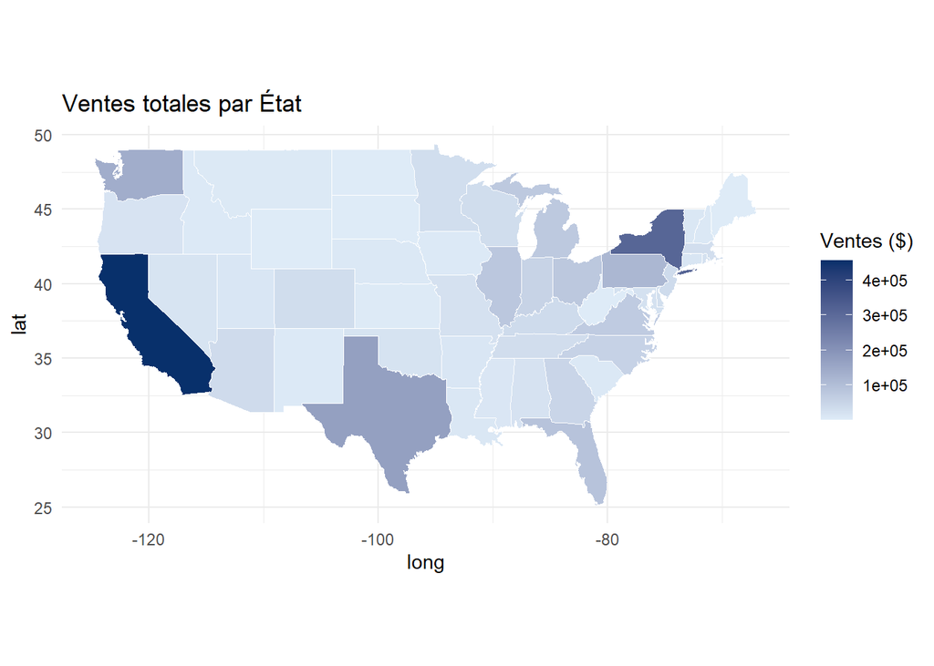

```r
ggplot(data_merged, aes(
  x = long, y = lat, group = group, fill = total_sales,
  text = paste0("État : ", str_to_title(region), "<br>Ventes : ", scales::comma(total_sales))
)) +
  geom_polygon(color = "white", linewidth = 0.1) +
  scale_fill_gradient(low = "#deebf7", high = "#08306b", na.value = "grey90") +
  coord_fixed(1.3) +
  labs(title = "Ventes totales par État", fill = "Ventes ($)") +
  theme_minimal()
```

```r
#ggplotly(p, tooltip = "text")
```

```r
marge_by_states <- df |>
  mutate(region = tolower(State)) |>
  group_by(region) |>
  summarise(total_marge = sum(marge))
```

```r
marge_merged <- us_states |> left_join(marge_by_states, by = "region")
```

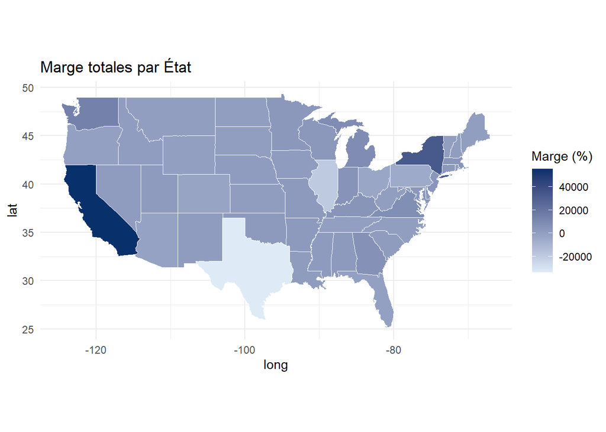

```r
ggplot(marge_merged, aes(
  x = long, y = lat, group = group, fill = total_marge,
  text = paste0("État : ", str_to_title(region), "<br>Ventes : ", scales::comma(total_marge))
)) +
  geom_polygon(color = "white", linewidth = 0.1) +
  scale_fill_gradient(low = "#deebf7", high = "#08306b", na.value = "grey90") +
  coord_fixed(1.3) +
  labs(title = "Marge totales par État", fill = "Marge (%)") +
  theme_minimal()
```

```r
#ggplotly(p, tooltip = "text")
```

### Etude de l’incidence des discounts sur la marge

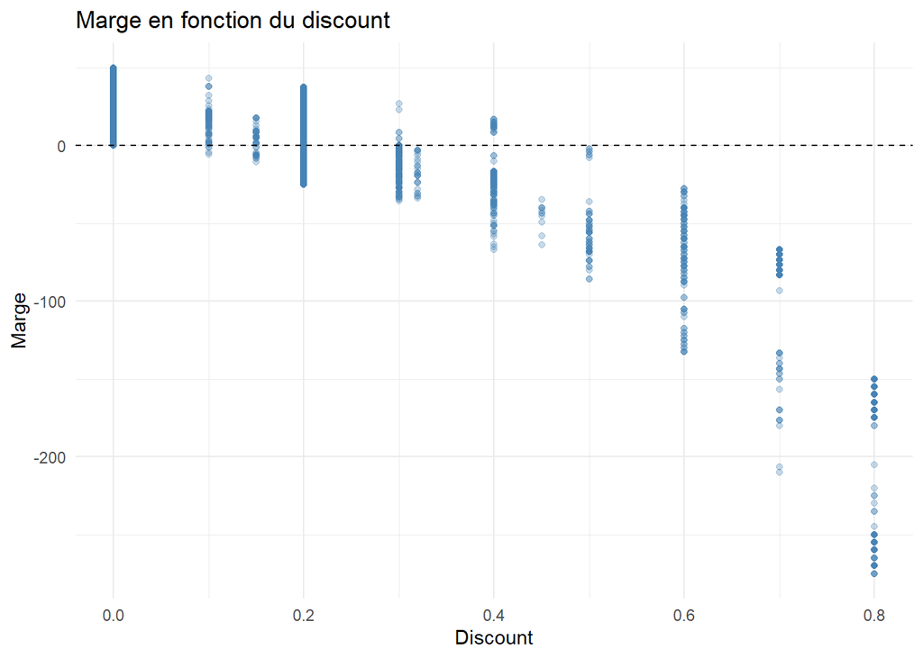

```r
df |> ggplot(aes(x = Discount, y = marge)) +
  geom_point(alpha = 0.3, color = "steelblue") +
  geom_hline(yintercept = 0, linetype = "dashed", color = "black") +
  labs(
    title = "Marge en fonction du discount",
    x = "Discount",
    y = "Marge"
  ) +
  theme_minimal()
```

```r
cor.test(df$marge, df$Discount, method = "spearman")
```

```
    Spearman's rank correlation rho

data:  df$marge and df$Discount
S = 2.7319e+11, p-value < 2.2e-16
alternative hypothesis: true rho is not equal to 0
sample estimates:
       rho
-0.6450828
```

Ci-dessus, nous représentons les marges de profit réalisées par l’entreprise en fonction du discount accordé. Nous constatons immédiatement une relation négative : plus le discount augmente, plus la marge s’effondre et ceci devient critique dès que l’entreprise atteint le pallier de discount de 50 %.

Un coefficient de corrélation de Spearman de **-0,6450828** confirme notre intuition graphique, la marge et le discount sont négativement corrélés.